# Hydrological Data EDA

## Load Packages & Data

In this excercise you will use use plyr and reshape to manipulate data and work with a time series of stream flow for the Ganges River. This example of EDA may be helpful for your time series data.

```r
library(ggplot2)
library(plyr)
library(reshape2)
ganges <- read.csv("gangesCMS.csv")
```

## Inspect Data

Use the functions head, str and summary that we previously learned to explore the Ganges data set. Then use sapply, a function that applies a function to a vector or dataframe, to count the number of missing values using a simple function.

```r
# review data
head(ganges)
```

```
##   Ganges  Jan  Feb  Mar  Apr  May  Jun   Jul   Aug   Sep   Oct  Nov  Dec
## 1   1934 2778 2458 2228 2138 1987 3613 19775 36277 40084 18625 6197 3432
## 2   1935 2389 2056 1625 1888 1654 2918 13086 38239 27645 13908 4531 3356
## 3   1936 2858 2312 2442 1434 1778 5189 22873 39497 38061 16688 6665 3830
## 4   1937 2630 2495 2392 1803 1877 3440 11893 33913 30065 18748 6379 3495
## 5   1938 2550 2176 2013 2216 2053 8557 28319 43681 33735 10132 4880 3254
## 6   1939 2291 2164 2096 1750 1790 3090 13052 28606 26545 12759 5277 3132
```

```r
str(ganges)
```

```
## 'data.frame':    80 obs. of  13 variables:
##  $ Ganges: int  1934 1935 1936 1937 1938 1939 1940 1941 1942 1943 ...
##  $ Jan   : int  2778 2389 2858 2630 2550 2291 2749 2389 2641 2585 ...
##  $ Feb   : int  2458 2056 2312 2495 2176 2164 2297 2247 2552 2352 ...
##  $ Mar   : int  2228 1625 2442 2392 2013 2096 1930 2271 2062 2396 ...
##  $ Apr   : int  2138 1888 1434 1803 2216 1750 1910 1565 1821 1810 ...
##  $ May   : int  1987 1654 1778 1877 2053 1790 1838 1915 1889 2022 ...
##  $ Jun   : int  3613 2918 5189 3440 8557 3090 2906 4224 2590 4742 ...
##  $ Jul   : int  19775 13086 22873 11893 28319 13052 12997 10760 17709 14023 ...
##  $ Aug   : int  36277 38239 39497 33913 43681 28606 30806 23584 39713 33952 ...
##  $ Sep   : int  40084 27645 38061 30065 33735 26545 25068 26823 36594 34858 ...
##  $ Oct   : int  18625 13908 16688 18748 10132 12759 8468 10305 14615 15699 ...
##  $ Nov   : int  6197 4531 6665 6379 4880 5277 4372 4670 5589 6571 ...
##  $ Dec   : int  3432 3356 3830 3495 3254 3132 3203 2996 3379 3496 ...
```

```r
summary(ganges)
```

```
##      Ganges          Jan            Feb            Mar            Apr
##  Min.   :1934   Min.   :1152   Min.   : 541   Min.   : 316   Min.   : 400.0
##  1st Qu.:1954   1st Qu.:1658   1st Qu.:1339   1st Qu.: 956   1st Qu.: 939.5
##  Median :1974   Median :2442   Median :2028   Median :1734   Median :1593.0
##  Mean   :1974   Mean   :2520   Mean   :2001   Mean   :1656   Mean   :1509.2
##  3rd Qu.:1993   3rd Qu.:2910   3rd Qu.:2500   3rd Qu.:2216   3rd Qu.:1977.8
##  Max.   :2013   Max.   :8575   Max.   :4758   Max.   :3592   Max.   :2974.0
##
##       May            Jun            Jul             Aug             Sep
##  Min.   : 555   Min.   : 895   Min.   : 5848   Min.   :21939   Min.   :15179
##  1st Qu.:1328   1st Qu.:2894   1st Qu.:14218   1st Qu.:30985   1st Qu.:29594
##  Median :1734   Median :3933   Median :18399   Median :37980   Median :35448
##  Mean   :1748   Mean   :3991   Mean   :18873   Mean   :37236   Mean   :35987
##  3rd Qu.:2072   3rd Qu.:4836   3rd Qu.:22557   3rd Qu.:43708   3rd Qu.:40991
##  Max.   :3136   Max.   :9567   Max.   :31796   Max.   :53019   Max.   :56803
##                                                                NA's   :1
##       Oct             Nov             Dec
##  Min.   : 7630   Min.   : 2752   Min.   : 1955
##  1st Qu.:12660   1st Qu.: 4994   1st Qu.: 2870
##  Median :16868   Median : 6197   Median : 3405
##  Mean   :17374   Mean   : 6505   Mean   : 3762
##  3rd Qu.:20549   3rd Qu.: 7203   3rd Qu.: 4348
##  Max.   :42300   Max.   :16465   Max.   :14865
##  NA's   :1       NA's   :1       NA's   :1
```

```r
sapply(ganges, function(x) sum(is.na(x)))
```

```
## Ganges    Jan    Feb    Mar    Apr    May    Jun    Jul    Aug    Sep    Oct
##      0      0      0      0      0      0      0      0      0      1      1
##    Nov    Dec
##      1      1
```

Note the structure of the data. Each row in the data set is a year of monthly average streamflow observations. In analysis you may want to also know the annual mean flow. Compute the annual mean flow and add it to a new column.

```r
# Add annual mean flow column (named annual, added at end) and then rename first columns to year
ganges$annual <- rowSums(ganges[,2:13])/12
colnames(ganges)[1] <- 'year'
```

Next visually inspect the data using a series of plots using the base plotting functions available in R.

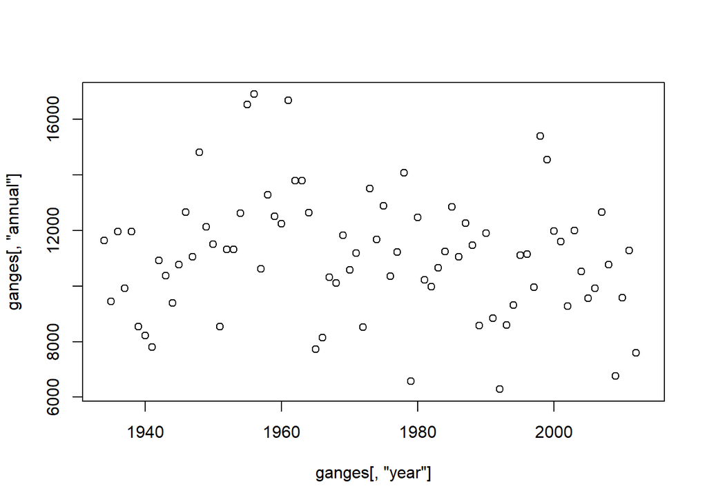

```r
# Test plots
plot(ganges[,'year'],ganges[,'annual'])
```

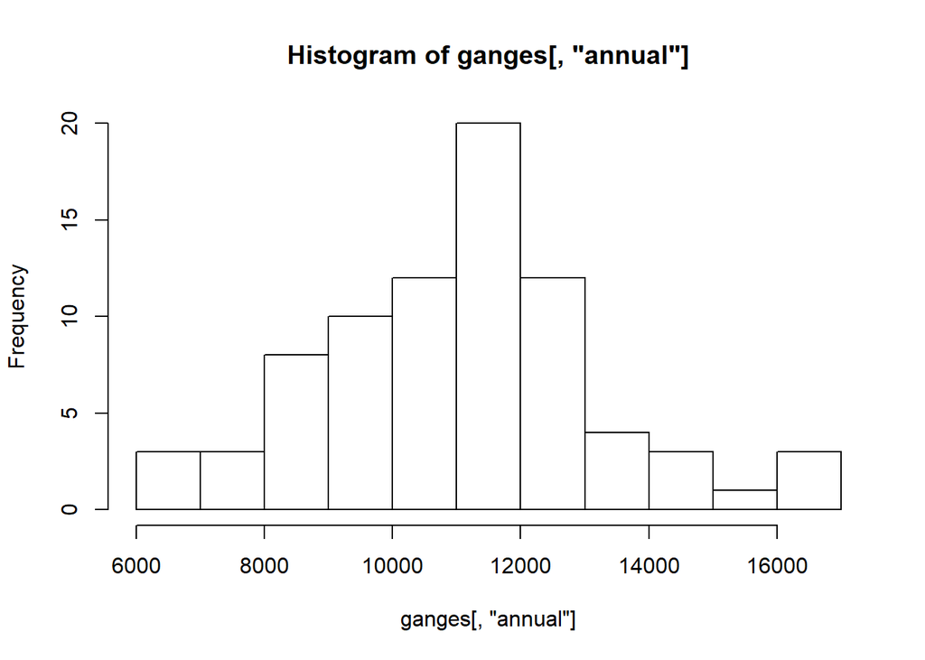

```r
hist(ganges[,'annual'])
```

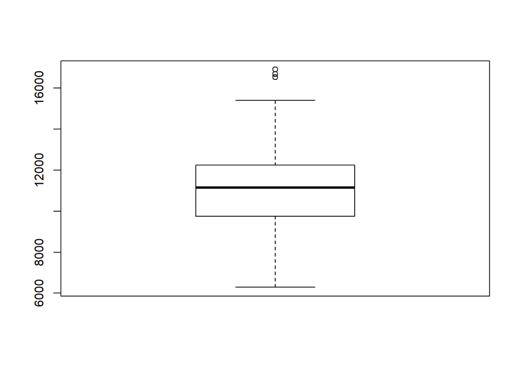

```r
boxplot(ganges[,'annual'])
```

## Rearrange Data

Earlier we noted the structure of the data is rows for each year and columns for each month. This structure makes it more challenging to conduct analyses and prepare plots. So, we will rearrange the data in a time series, where there is one column for streamflow and each row is a monthly observation.

```r
# Melt data frame for ggplot
ganges <- subset(ganges, select = -14) # remove annual average
ganges <- melt(ganges, id=c("year")) # reshape data
ganges <- arrange(ganges, year) #order data by year of observation
ganges$index <- 1:nrow(ganges) # create an index column (numbers the observations)
colnames(ganges) <- c('year','month','flow','index') # rename columns for easy reference
```

## Plotting with ggplot

Now practice applying plotting functions from the ggplot (grammar of graphics) package that we previsouly explored.

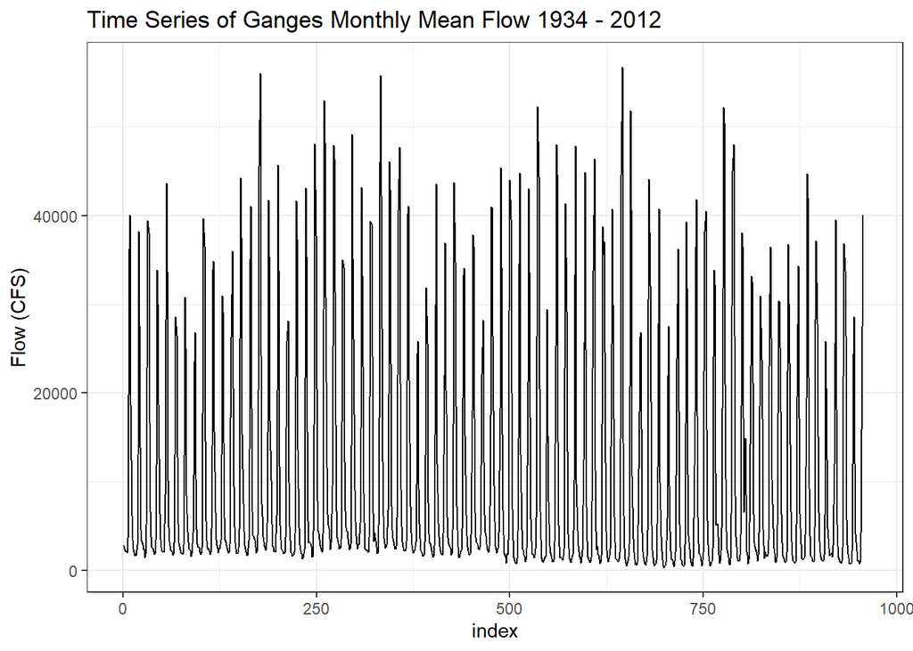

```r
# plot time series
p1 <- ggplot(ganges, aes(y=flow, x=index)) + geom_line() +
  ggtitle(paste("Time Series of Ganges Monthly Mean Flow 1934 - 2012")) +
  ylab("Flow (CFS)") + theme_bw()
p1
```

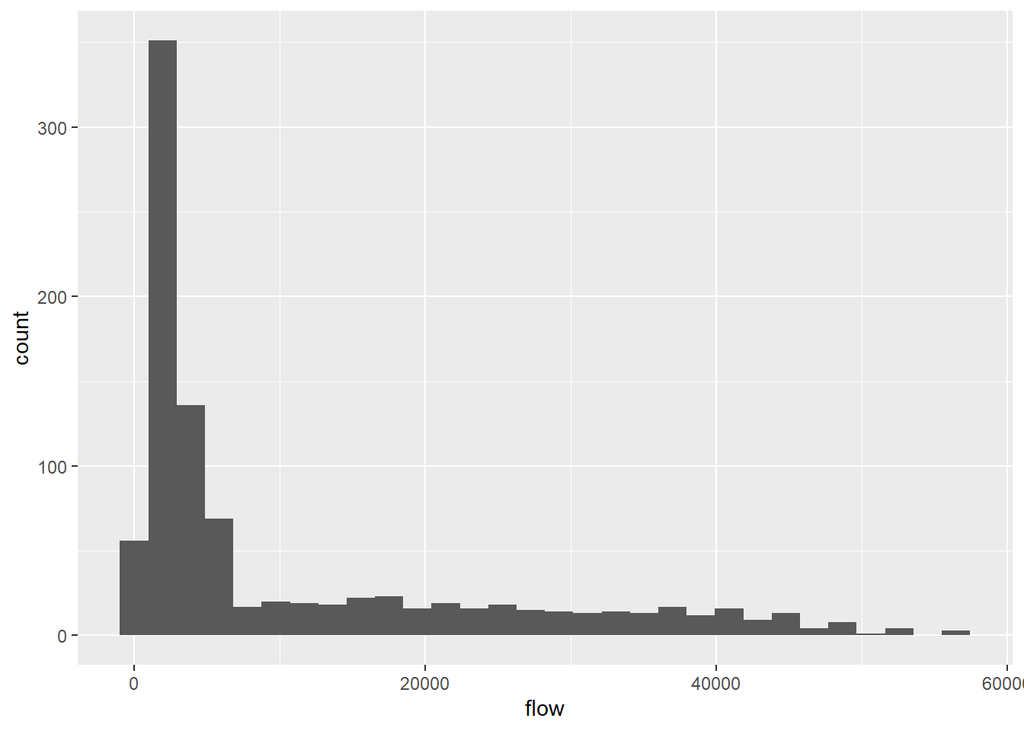

```r
# Visualizing distributions of a single variable
ggplot(data = ganges, aes(x = flow)) + geom_histogram()
```

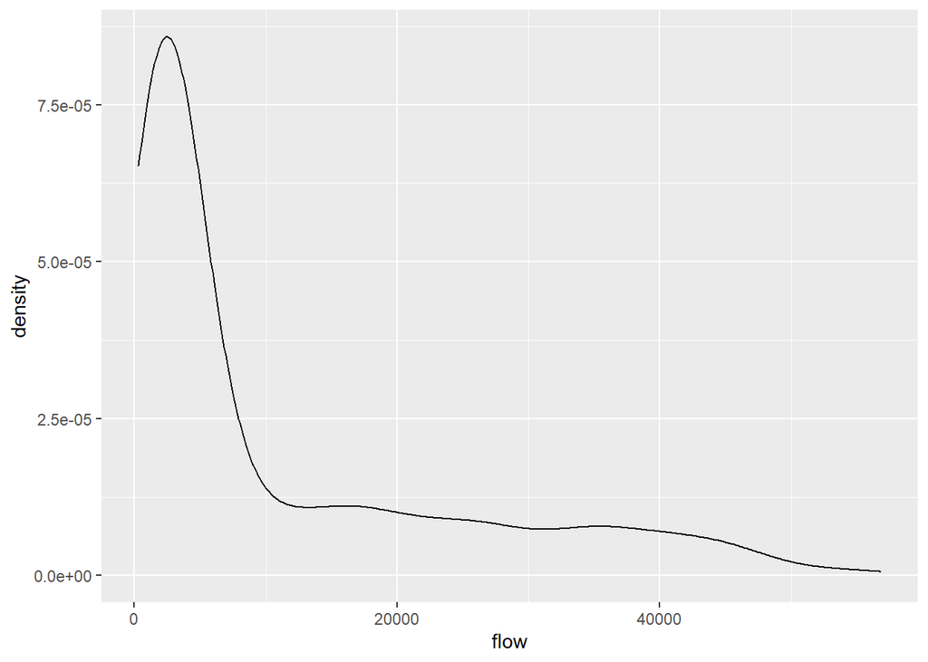

```r
ggplot(data = ganges, aes(x = flow)) + geom_density()
```

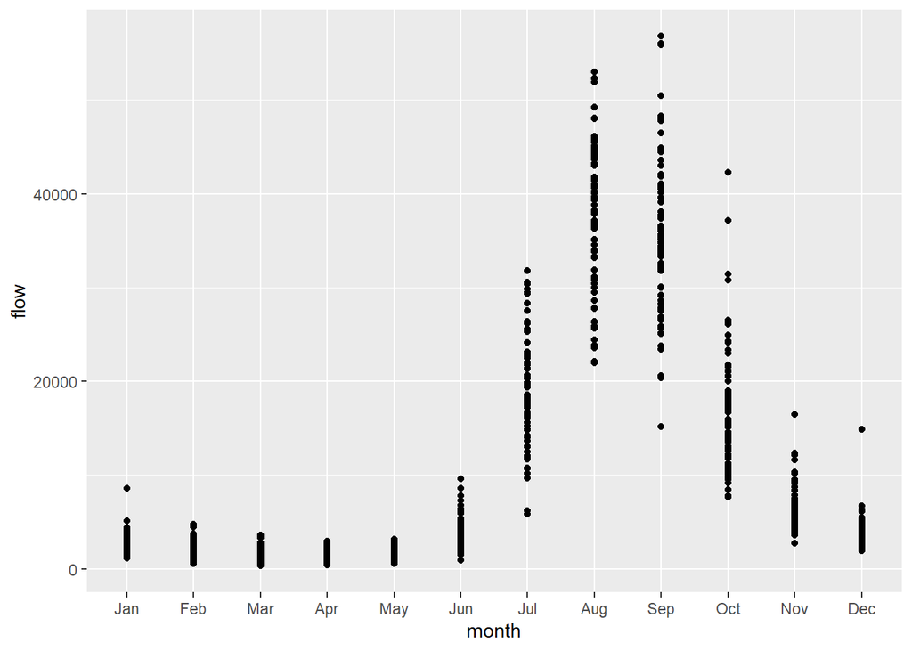

```r
# Visualize data by month
ggplot(ganges, aes(y=flow, x=month)) + geom_point()
```

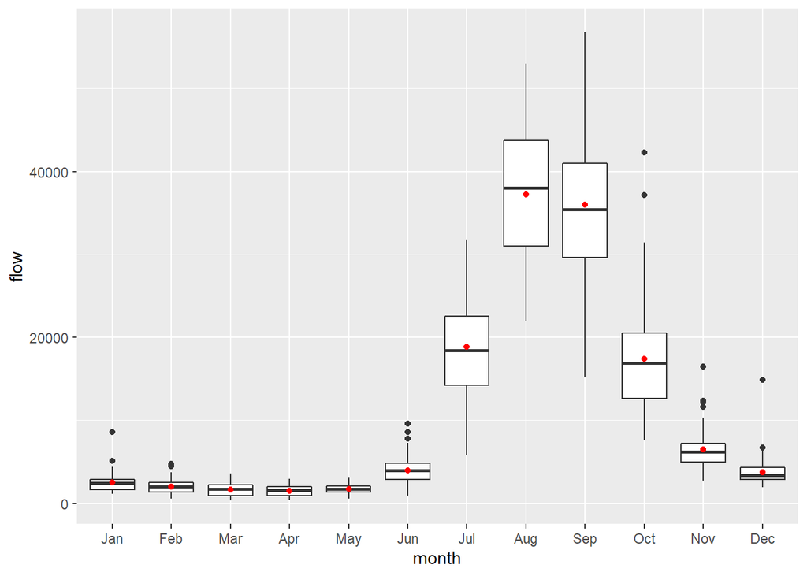

```r
ggplot(data = ganges, aes(x = month, y = flow)) +
  geom_boxplot() +
  stat_summary(fun = "mean", color = "red", geom = "point")
```